# Space-Time Prediction of Bike Share Demand: Philadelphia Indego - Q2 2024

Author

Zhiyuan Zhao & Fan Yang

Published

November 18, 2025

# Introduction

## The Rebalancing Challenge in Philadelphia

Philadelphia’s Indego bike share system faces the same operational challenge as every bike share system: **rebalancing bikes to meet anticipated demand**.

This analysis applies space-time prediction models to **Q2 2024 (April-June)** Indego data to forecast bike share demand across different stations and time periods.

# Setup

## Load Libraries

```r
# Core tidyverse packages
library(tidyverse)
library(lubridate)

# Spatial data packages
library(sf)
library(tigris)

# Census data
library(tidycensus)

# Weather data from ASOS stations
library(riem)

# Visualization packages
library(viridis)
library(gridExtra)
library(knitr)
library(kableExtra)

# File path management
library(here)

# Remove scientific notation for better readability
options(scipen = 999)
options(tigris_use_cache = TRUE)
```

## Define Themes

```r
# Custom plot theme for consistent visualization
plotTheme <- theme(
  plot.title = element_text(size = 14, face = "bold"),
  plot.subtitle = element_text(size = 10),
  plot.caption = element_text(size = 8),
  axis.text.x = element_text(size = 10, angle = 45, hjust = 1),
  axis.text.y = element_text(size = 10),
  axis.title = element_text(size = 11, face = "bold"),
  panel.background = element_blank(),
  panel.grid.major = element_line(colour = "#D0D0D0", size = 0.2),
  panel.grid.minor = element_blank(),
  axis.ticks = element_blank(),
  legend.position = "right"
)

# Custom map theme for spatial visualizations
mapTheme <- theme(
  plot.title = element_text(size = 14, face = "bold"),
  plot.subtitle = element_text(size = 10),
  plot.caption = element_text(size = 8),
  axis.line = element_blank(),
  axis.text = element_blank(),
  axis.ticks = element_blank(),
  axis.title = element_blank(),
  panel.background = element_blank(),
  panel.border = element_blank(),
  panel.grid.major = element_line(colour = 'transparent'),
  panel.grid.minor = element_blank(),
  legend.position = "right",
  plot.margin = margin(1, 1, 1, 1, 'cm'),
  legend.key.height = unit(1, "cm"),
  legend.key.width = unit(0.2, "cm")
)

# Color palette for visualizations
palette5 <- c("#eff3ff", "#bdd7e7", "#6baed6", "#3182bd", "#08519c")
```

## Set Census API Key

```r
# Set Census API key
census_api_key("API_KEY", overwrite = TRUE, install = TRUE)
```

# Data Import & Preparation

## Load Indego Trip Data (Q2 2024)

```r
# Read Q2 2024 data (April - June 2024) using relative path
indego <- read_csv("/Users/zhaozhiyuan/Documents/GitHub/portfolio-setup-ZhiyuanZhaoMicheal/Assignments/assignment_5/data/indego-trips-2024-q2.csv")
```

## Examine the Data Structure

```r
# Create summary statistics data frame
summary_stats <- data.frame(
  Metric = c("Total Trips",
             "Date Range",
             "Unique Start Stations"),
  Value = c(
    format(nrow(indego), big.mark = ","),
    paste(min(mdy_hm(indego$start_time)), "to", max(mdy_hm(indego$start_time))),
    length(unique(indego$start_station))
  )
)

# Display summary table
kable(summary_stats,
      caption = "Q2 2024 Indego Data Overview",
      col.names = c("Metric", "Value")) %>%
  kable_styling(bootstrap_options = c("striped", "hover"),
                full_width = FALSE)
```

Q2 2024 Indego Data Overview

| Metric | Value |
| --- | --- |
| Total Trips | 368,091 |
| Date Range | 2024-04-01 to 2024-06-30 23:56:00 |
| Unique Start Stations | 255 |

```r
# Trip types
trip_types <- as.data.frame(table(indego$trip_route_category))
colnames(trip_types) <- c("Trip Type", "Count")
trip_types$Percentage <- round(trip_types$Count / sum(trip_types$Count) * 100, 1)

kable(trip_types,
      caption = "Trip Route Categories",
      format.args = list(big.mark = ",")) %>%
  kable_styling(bootstrap_options = c("striped", "hover"),
                full_width = FALSE)
```

Trip Route Categories

| Trip Type | Count | Percentage |
| --- | --- | --- |
| One Way | 342,299 | 93 |
| Round Trip | 25,792 | 7 |

```r
# Passholder types
passholder <- as.data.frame(table(indego$passholder_type))
colnames(passholder) <- c("Passholder Type", "Count")
passholder$Percentage <- round(passholder$Count / sum(passholder$Count) * 100, 1)

kable(passholder,
      caption = "Passholder Types",
      format.args = list(big.mark = ",")) %>%
  kable_styling(bootstrap_options = c("striped", "hover"),
                full_width = FALSE)
```

Passholder Types

| Passholder Type | Count | Percentage |
| --- | --- | --- |
| Day Pass | 20,926 | 5.7 |
| Indego30 | 231,909 | 63.0 |
| Indego365 | 115,256 | 31.3 |

```r
# Bike types
bike_types <- as.data.frame(table(indego$bike_type))
colnames(bike_types) <- c("Bike Type", "Count")
bike_types$Percentage <- round(bike_types$Count / sum(bike_types$Count) * 100, 1)

kable(bike_types,
      caption = "Bike Types",
      format.args = list(big.mark = ",")) %>%
  kable_styling(bootstrap_options = c("striped", "hover"),
                full_width = FALSE)
```

Bike Types

| Bike Type | Count | Percentage |
| --- | --- | --- |
| electric | 216,497 | 58.8 |
| standard | 151,594 | 41.2 |

## Create Time Bins

```r
indego <- indego %>%
  mutate(
    # Parse datetime strings to datetime objects
    start_datetime = mdy_hm(start_time),
    end_datetime = mdy_hm(end_time),

    # Create hourly time bins for aggregation
    interval60 = floor_date(start_datetime, unit = "hour"),

    # Extract temporal features
    week = week(interval60),
    month = month(interval60, label = TRUE),
    dotw = wday(interval60, label = TRUE),
    hour = hour(interval60),
    date = as.Date(interval60),

    # Create binary indicators for useful categories
    weekend = ifelse(dotw %in% c("Sat", "Sun"), 1, 0),
    rush_hour = ifelse(hour %in% c(7, 8, 9, 16, 17, 18), 1, 0)
  )
```

# Exploratory Analysis

## Trips Over Time

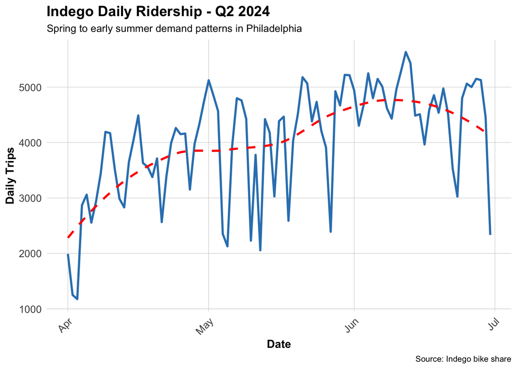

```r
# Aggregate trips by date
daily_trips <- indego %>%
  group_by(date) %>%
  summarize(trips = n())

# Plot daily ridership trends
ggplot(daily_trips, aes(x = date, y = trips)) +
  geom_line(color = "#3182bd", linewidth = 1) +
  geom_smooth(se = FALSE, color = "red", linetype = "dashed") +
  labs(
    title = "Indego Daily Ridership - Q2 2024",
    subtitle = "Spring to early summer demand patterns in Philadelphia",
    x = "Date",
    y = "Daily Trips",
    caption = "Source: Indego bike share"
  ) +
  plotTheme
```

During the second quarter of 2024 (April to June), overall bicycle usage showed an upward trend, indicating that weather and seasonal factors exert a certain influence on demand for shared bicycles.

## Hourly Patterns

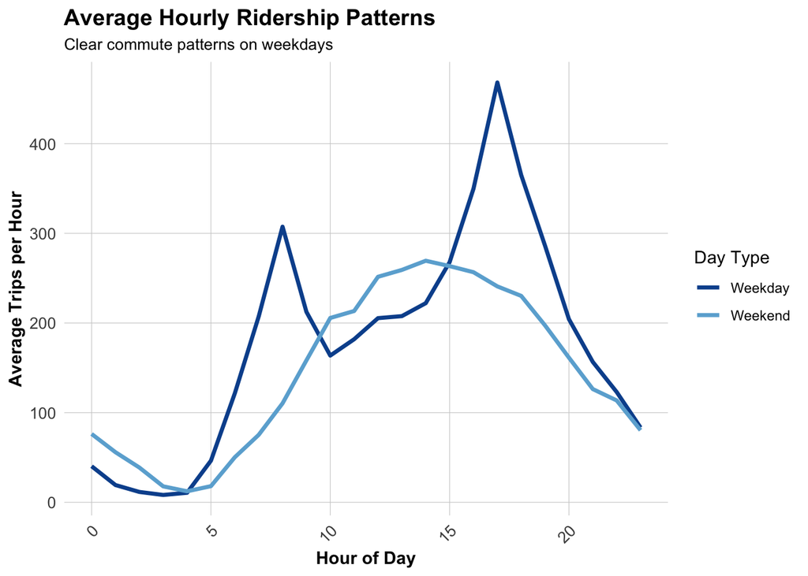

```r
# Calculate average trips by hour and weekend/weekday
hourly_patterns <- indego %>%
  group_by(hour, weekend) %>%
  summarize(avg_trips = n() / n_distinct(date), .groups = "drop") %>%
  mutate(day_type = ifelse(weekend == 1, "Weekend", "Weekday"))

# Plot hourly patterns
ggplot(hourly_patterns, aes(x = hour, y = avg_trips, color = day_type)) +
  geom_line(linewidth = 1.2) +
  scale_color_manual(values = c("Weekday" = "#08519c", "Weekend" = "#6baed6")) +
  labs(
    title = "Average Hourly Ridership Patterns",
    subtitle = "Clear commute patterns on weekdays",
    x = "Hour of Day",
    y = "Average Trips per Hour",
    color = "Day Type"
  ) +
  plotTheme
```

Weekday rush hours (7-9 a.m. and 4-6 p.m.) exhibit distinct patterns, while weekend demand is more evenly distributed between 7 a.m. and 10 p.m., with only a single peak occurring in the afternoon. It can be concluded that Indego serves different needs on weekdays (commuting) and weekends (leisure).

## Top Stations

```r
# Identify most popular origin stations
top_stations <- indego %>%
  count(start_station, start_lat, start_lon, name = "trips") %>%
  arrange(desc(trips)) %>%
  head(20)

# Display table of top stations
kable(top_stations,
      caption = "Top 20 Most Popular Origin Stations",
      format.args = list(big.mark = ","),
      digits = 4) %>%
  kable_styling(bootstrap_options = c("striped", "hover"))
```

Top 20 Most Popular Origin Stations

| start_station | start_lat | start_lon | trips |
| --- | --- | --- | --- |
| 3,010 | 39.9471 | -75.1662 | 6,115 |
| 3,032 | 39.9453 | -75.1797 | 5,231 |
| 3,295 | 39.9503 | -75.1603 | 4,451 |
| 3,359 | 39.9489 | -75.1698 | 4,248 |
| 3,022 | 39.9547 | -75.1832 | 4,070 |
| 3,028 | 39.9406 | -75.1496 | 4,052 |
| 3,066 | 39.9456 | -75.1735 | 4,047 |
| 3,054 | 39.9625 | -75.1742 | 3,847 |
| 3,020 | 39.9486 | -75.1901 | 3,792 |
| 3,208 | 39.9505 | -75.1932 | 3,661 |
| 3,052 | 39.9473 | -75.1570 | 3,651 |
| 3,012 | 39.9422 | -75.1775 | 3,573 |
| 3,163 | 39.9497 | -75.1810 | 3,558 |
| 3,244 | 39.9386 | -75.1667 | 3,549 |
| 3,185 | 39.9517 | -75.1589 | 3,523 |
| 3,007 | 39.9452 | -75.1599 | 3,492 |
| 3,059 | 39.9624 | -75.1612 | 3,470 |
| 3,362 | 39.9482 | -75.1623 | 3,443 |
| 3,101 | 39.9430 | -75.1596 | 3,425 |
| 3,063 | 39.9463 | -75.1698 | 3,404 |

# Create Panel Data Structure

## Generate Station-Hour Combinations

```r
# Extract unique stations with coordinates
stations <- indego %>%
  distinct(start_station, start_lat, start_lon)

# Create complete hourly time sequence
time_sequence <- data.frame(
  interval60 = seq(
    from = min(indego$interval60),
    to = max(indego$interval60),
    by = "hour"
  )
)

# Generate full panel structure (all station-hour combinations)
study_panel <- expand.grid(
  start_station = stations$start_station,
  interval60 = time_sequence$interval60
) %>%
  # Add station coordinates
  left_join(stations, by = "start_station") %>%
  # Add actual trip counts
  left_join(
    indego %>%
      count(start_station, interval60, name = "trips"),
    by = c("start_station", "interval60")
  ) %>%
  # Replace NA with 0 (no trips in that hour)
  mutate(trips = replace_na(trips, 0))

# Add temporal features to panel
study_panel <- study_panel %>%
  mutate(
    week = week(interval60),
    month = month(interval60, label = TRUE),
    dotw = wday(interval60, label = TRUE),
    hour = hour(interval60),
    date = as.Date(interval60),
    weekend = ifelse(dotw %in% c("Sat", "Sun"), 1, 0),
    rush_hour = ifelse(hour %in% c(7, 8, 9, 16, 17, 18), 1, 0),
    # Create time of day categories
    time_of_day = case_when(
      hour >= 6 & hour < 9 ~ "Morning Rush",
      hour >= 9 & hour < 16 ~ "Midday",
      hour >= 16 & hour < 19 ~ "Evening Rush",
      hour >= 19 & hour < 22 ~ "Evening",
      TRUE ~ "Night/Early Morning"
    )
  )

# Display panel structure summary
panel_summary <- data.frame(
  Metric = c("Number of Observations",
             "Number of Stations",
             "Number of Time Periods",
             "Average Trips per Station-Hour",
             "Median Trips per Station-Hour",
             "Total Trips in Panel"),
  Value = c(
    format(nrow(study_panel), big.mark = ","),
    length(unique(study_panel$start_station)),
    length(unique(study_panel$interval60)),
    round(mean(study_panel$trips), 2),
    median(study_panel$trips),
    format(sum(study_panel$trips), big.mark = ",")
  )
)

kable(panel_summary,
      caption = "Panel Data Structure Summary",
      col.names = c("Metric", "Value")) %>%
  kable_styling(bootstrap_options = c("striped", "hover"),
                full_width = FALSE)
```

Panel Data Structure Summary

| Metric | Value |
| --- | --- |
| Number of Observations | 556,920 |
| Number of Stations | 255 |
| Number of Time Periods | 2184 |
| Average Trips per Station-Hour | 0.66 |
| Median Trips per Station-Hour | 0 |
| Total Trips in Panel | 368,091 |

# Weather Data

## Get Philadelphia Weather

```r
# Fetch weather data from Philadelphia International Airport
# Q2 2024: April 1 - June 30, 2024
weather <- riem_measures(
  station = "PHL",
  date_start = "2024-04-01",
  date_end = "2024-06-30"
)
```

```r
# Clean and process weather data
weather_clean <- weather %>%
  select(
    valid,
    tmpf,      # Temperature (Fahrenheit)
    dwpf,      # Dew point (Fahrenheit)
    relh,      # Relative humidity (%)
    sknt,      # Wind speed (knots)
    p01i,      # Precipitation (inches)
    vsby       # Visibility (miles)
  ) %>%
  mutate(
    # Round to hourly intervals
    interval60 = floor_date(ymd_hms(valid), unit = "hour"),

    # Categorize temperature
    temp_cat = case_when(
      tmpf < 32 ~ "Freezing",
      tmpf < 50 ~ "Cold",
      tmpf < 65 ~ "Cool",
      tmpf < 75 ~ "Pleasant",
      tmpf < 85 ~ "Warm",
      TRUE ~ "Hot"
    ),

    # Binary indicator for precipitation
    is_raining = ifelse(p01i > 0.01, 1, 0)
  ) %>%
  # Aggregate to hourly averages
  group_by(interval60) %>%
  summarize(
    temperature = mean(tmpf, na.rm = TRUE),
    wind_speed = mean(sknt, na.rm = TRUE),
    precipitation = sum(p01i, na.rm = TRUE),
    humidity = mean(relh, na.rm = TRUE),
    .groups = "drop"
  )

# Join weather data to panel
study_panel <- study_panel %>%
  left_join(weather_clean, by = "interval60")
```

Weather data successfully integrated for 98.9% of observations.

## Visualize Weather Impact

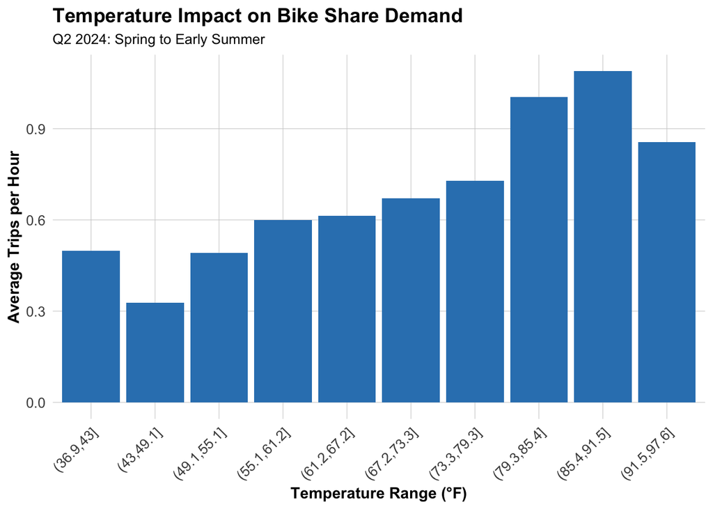

```r
# Analyze relationship between temperature and demand
temp_demand <- study_panel %>%
  filter(!is.na(temperature)) %>%
  mutate(temperature_bin = cut(temperature, breaks = 10)) %>%
  group_by(temperature_bin) %>%
  summarize(avg_trips = mean(trips), .groups = "drop")

# Plot temperature vs demand
ggplot(temp_demand, aes(x = temperature_bin, y = avg_trips)) +
  geom_col(fill = "#3182bd") +
  labs(
    title = "Temperature Impact on Bike Share Demand",
    subtitle = "Q2 2024: Spring to Early Summer",
    x = "Temperature Range (°F)",
    y = "Average Trips per Hour"
  ) +
  plotTheme +
  theme(axis.text.x = element_text(angle = 45, hjust = 1))
```

# Census Demographics

## Get Philadelphia Census Data

```r
# Fetch census tract data for Philadelphia
philly_census <- get_acs(
  geography = "tract",
  variables = c(
    "B01003_001",  # Total population
    "B19013_001",  # Median household income
    "B08301_001",  # Total commuters
    "B08301_010",  # Commute by transit
    "B02001_001",  # Total race population
    "B02001_002"   # White alone
  ),
  state = "PA",
  county = "Philadelphia",
  year = 2022,
  geometry = TRUE,
  output = "wide"
)
```

```r
philly_census <- philly_census %>%
  # Transform to WGS84 coordinate system
  st_transform(4326) %>%
  # Rename variables for clarity
  rename(
    Total_Pop = B01003_001E,
    Med_Inc = B19013_001E,
    Total_Commuters = B08301_001E,
    Transit_Commuters = B08301_010E,
    Total_Race = B02001_001E,
    White_Pop = B02001_002E
  ) %>%
  # Calculate percentages
  mutate(
    Percent_Taking_Transit = Transit_Commuters / Total_Commuters * 100,
    Percent_White = White_Pop / Total_Race * 100
  )
```

## Join Stations to Census Tracts

```r
# Convert stations dataframe to spatial object
# Remove stations with missing coordinates
stations_clean <- stations %>%
  filter(!is.na(start_lon) & !is.na(start_lat))

# Convert to spatial object
stations_sf <- stations_clean %>%
  st_as_sf(coords = c("start_lon", "start_lat"), crs = 4326)

# Spatial join: assign each station to its census tract
station_attributes <- stations_sf %>%
  st_join(philly_census) %>%
  st_drop_geometry() %>%
  select(start_station, Med_Inc, Percent_Taking_Transit, Percent_White)

# Add demographic attributes to panel
study_panel <- study_panel %>%
  left_join(station_attributes, by = "start_station")
```

# Create Temporal Lag Features

```r
# Sort data by station and time for proper lag calculation
study_panel <- study_panel %>%
  arrange(start_station, interval60)

# Create lag features to capture temporal autocorrelation
study_panel <- study_panel %>%
  group_by(start_station) %>%
  mutate(
    lag_1hr = lag(trips, 1),      # Trips 1 hour ago
    lag_2hr = lag(trips, 2),      # Trips 2 hours ago
    lag_3hr = lag(trips, 3),      # Trips 3 hours ago
    lag_24hr = lag(trips, 24),    # Trips 24 hours ago (same time yesterday)
    lag_1week = lag(trips, 168)   # Trips 1 week ago (same hour, same day)
  ) %>%
  ungroup()
```

# Train/Test Split

```r
# Use temporal split: first 80% for training, last 20% for testing
split_date <- quantile(study_panel$interval60, 0.8)

# Create training set
train <- study_panel %>%
  filter(interval60 < split_date) %>%
  filter(!is.na(lag_1hr))  # Remove rows with NA lags

# Create test set
test <- study_panel %>%
  filter(interval60 >= split_date) %>%
  filter(!is.na(lag_1hr))

# Display split summary
split_summary <- data.frame(
  Dataset = c("Training Set", "Test Set"),
  Observations = c(format(nrow(train), big.mark = ","),
                   format(nrow(test), big.mark = ",")),
  `Start Date` = c(as.character(min(train$date)),
                   as.character(min(test$date))),
  `End Date` = c(as.character(max(train$date)),
                 as.character(max(test$date))),
  check.names = FALSE
)

kable(split_summary,
      caption = "Train/Test Split Summary") %>%
  kable_styling(bootstrap_options = c("striped", "hover"),
                full_width = FALSE)
```

Train/Test Split Summary

| Dataset | Observations | Start Date | End Date |
| --- | --- | --- | --- |
| Training Set | 445,230 | 2024-04-01 | 2024-06-12 |
| Test Set | 111,435 | 2024-06-12 | 2024-06-30 |

# Part 1: Model Building

## Model 1: Temporal Features Only

```r
# Baseline model with only temporal features
model1 <- lm(
  trips ~ hour + dotw + month,
  data = train
)

# Generate predictions on test set
test <- test %>%
  mutate(
    pred_model1 = predict(model1, newdata = test),
    pred_model1 = pmax(pred_model1, 0)  # Ensure non-negative predictions
  )
```

```r
# Calculate Mean Absolute Error
mae1 <- mean(abs(test$trips - test$pred_model1), na.rm = TRUE)
data.frame(
  Metric = "MAE",
  Value = round(mae1, 3)
) %>%
  kable(col.names = c("Metric", "Value")) %>%
  kable_styling(bootstrap_options = c("striped", "hover"), full_width = FALSE)
```

| Metric | Value |
| --- | --- |
| MAE | 0.915 |

## Model 2: Add Weather

```r
# Add weather features to the model
model2 <- lm(
  trips ~ hour + dotw + month + temperature + precipitation + wind_speed,
  data = train
)

# Generate predictions
test <- test %>%
  mutate(
    pred_model2 = predict(model2, newdata = test),
    pred_model2 = pmax(pred_model2, 0)
  )
```

```r
# Calculate MAE
mae2 <- mean(abs(test$trips - test$pred_model2), na.rm = TRUE)
data.frame(
  Metric = c("MAE", "Improvement vs Model 1"),
  Value = c(round(mae2, 3), paste0(round((mae1 - mae2) / mae1 * 100, 2), "%"))
) %>%
  kable(col.names = c("Metric", "Value")) %>%
  kable_styling(bootstrap_options = c("striped", "hover"), full_width = FALSE)
```

| Metric | Value |
| --- | --- |
| MAE | 0.949 |
| Improvement vs Model 1 | -3.76% |

## Model 3: Add Lag Features

```r
# Add temporal lag features (demand persistence)
model3 <- lm(
  trips ~ hour + dotw + month + temperature + precipitation +
    lag_1hr + lag_2hr + lag_24hr,
  data = train
)

# Generate predictions
test <- test %>%
  mutate(
    pred_model3 = predict(model3, newdata = test),
    pred_model3 = pmax(pred_model3, 0)
  )
```

```r
# Calculate MAE
mae3 <- mean(abs(test$trips - test$pred_model3), na.rm = TRUE)
data.frame(
  Metric = c("MAE", "Improvement vs Model 1"),
  Value = c(round(mae3, 3), paste0(round((mae1 - mae3) / mae1 * 100, 2), "%"))
) %>%
  kable(col.names = c("Metric", "Value")) %>%
  kable_styling(bootstrap_options = c("striped", "hover"), full_width = FALSE)
```

| Metric | Value |
| --- | --- |
| MAE | 0.742 |
| Improvement vs Model 1 | 18.9% |

## Model 4: Add Demographics

```r
# Add demographic features
model4 <- lm(
  trips ~ hour + dotw + month + temperature + precipitation +
    lag_1hr + lag_2hr + lag_24hr + Med_Inc + Percent_Taking_Transit,
  data = train
)

# Generate predictions
test <- test %>%
  mutate(
    pred_model4 = predict(model4, newdata = test),
    pred_model4 = pmax(pred_model4, 0)
  )
```

```r
# Calculate MAE
mae4 <- mean(abs(test$trips - test$pred_model4), na.rm = TRUE)
data.frame(
  Metric = c("MAE", "Improvement vs Model 1"),
  Value = c(round(mae4, 3), paste0(round((mae1 - mae4) / mae1 * 100, 2), "%"))
) %>%
  kable(col.names = c("Metric", "Value")) %>%
  kable_styling(bootstrap_options = c("striped", "hover"), full_width = FALSE)
```

| Metric | Value |
| --- | --- |
| MAE | 0.746 |
| Improvement vs Model 1 | 18.42% |

## Model 5: Add Interactions

```r
# Add interaction terms to capture non-linear relationships
model5 <- lm(
  trips ~ hour + dotw + month + temperature + precipitation +
    lag_1hr + lag_2hr + lag_24hr + Med_Inc + Percent_Taking_Transit +
    temperature:weekend + rush_hour:lag_1hr,
  data = train
)

# Generate predictions
test <- test %>%
  mutate(
    pred_model5 = predict(model5, newdata = test),
    pred_model5 = pmax(pred_model5, 0)
  )
```

```r
# Calculate MAE
mae5 <- mean(abs(test$trips - test$pred_model5), na.rm = TRUE)
data.frame(
  Metric = c("MAE", "Improvement vs Model 1"),
  Value = c(round(mae5, 3), paste0(round((mae1 - mae5) / mae1 * 100, 2), "%"))
) %>%
  kable(col.names = c("Metric", "Value")) %>%
  kable_styling(bootstrap_options = c("striped", "hover"), full_width = FALSE)
```

| Metric | Value |
| --- | --- |
| MAE | 0.744 |
| Improvement vs Model 1 | 18.63% |

## Model Comparison

```r
# Create comparison table
model_results <- data.frame(
  Model = c("Model 1: Temporal",
            "Model 2: + Weather",
            "Model 3: + Lags",
            "Model 4: + Demographics",
            "Model 5: + Interactions"),
  MAE = c(mae1, mae2, mae3, mae4, mae5),
  Improvement = c(NA,
                  (mae1 - mae2) / mae1 * 100,
                  (mae1 - mae3) / mae1 * 100,
                  (mae1 - mae4) / mae1 * 100,
                  (mae1 - mae5) / mae1 * 100)
)

# Display comparison table
kable(model_results,
      digits = 3,
      caption = "Model Performance Comparison - Q2 2024",
      col.names = c("Model", "MAE", "Improvement vs. Model 1 (%)")) %>%
  kable_styling(bootstrap_options = c("striped", "hover"))
```

Model Performance Comparison - Q2 2024

| Model | MAE | Improvement vs. Model 1 (%) |
| --- | --- | --- |
| Model 1: Temporal | 0.915 | NA |
| Model 2: + Weather | 0.949 | -3.756 |
| Model 3: + Lags | 0.742 | 18.902 |
| Model 4: + Demographics | 0.746 | 18.416 |
| Model 5: + Interactions | 0.744 | 18.626 |

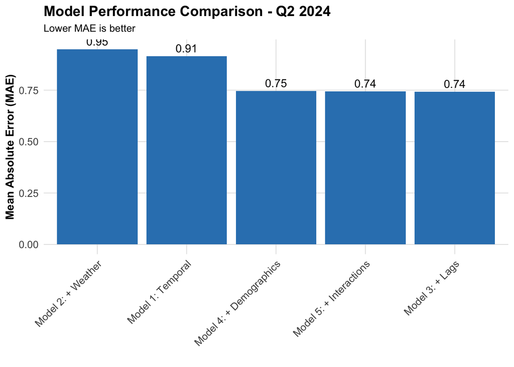

```r
# Visualize model performance
ggplot(model_results, aes(x = reorder(Model, -MAE), y = MAE)) +
  geom_col(fill = "#3182bd") +
  geom_text(aes(label = round(MAE, 2)), vjust = -0.5) +
  labs(
    title = "Model Performance Comparison - Q2 2024",
    subtitle = "Lower MAE is better",
    x = "",
    y = "Mean Absolute Error (MAE)"
  ) +
  plotTheme +
  theme(axis.text.x = element_text(angle = 45, hjust = 1))
```

# Part 2: Error Analysis

## Calculate Error Metrics

```r
# Use best model (Model 5) for error analysis
test <- test %>%
  mutate(
    prediction = pred_model5,
    error = trips - prediction,
    abs_error = abs(error),
    pct_error = ifelse(trips > 0, abs_error / trips * 100, NA)
  )

# Overall error statistics
error_stats <- data.frame(
  Metric = c("MAE", "RMSE", "Mean Percentage Error", "Median Percentage Error"),
  Value = c(
    round(mean(test$abs_error, na.rm = TRUE), 3),
    round(sqrt(mean(test$error^2, na.rm = TRUE)), 3),
    paste0(round(mean(test$pct_error, na.rm = TRUE), 1), "%"),
    paste0(round(median(test$pct_error, na.rm = TRUE), 1), "%")
  )
)

kable(error_stats,
      caption = "Overall Error Statistics",
      col.names = c("Metric", "Value")) %>%
  kable_styling(bootstrap_options = c("striped", "hover"),
                full_width = FALSE)
```

Overall Error Statistics

| Metric | Value |
| --- | --- |
| MAE | 0.744 |
| RMSE | 1.114 |
| Mean Percentage Error | 52.2% |
| Median Percentage Error | 50.6% |

## Spatial Error Patterns

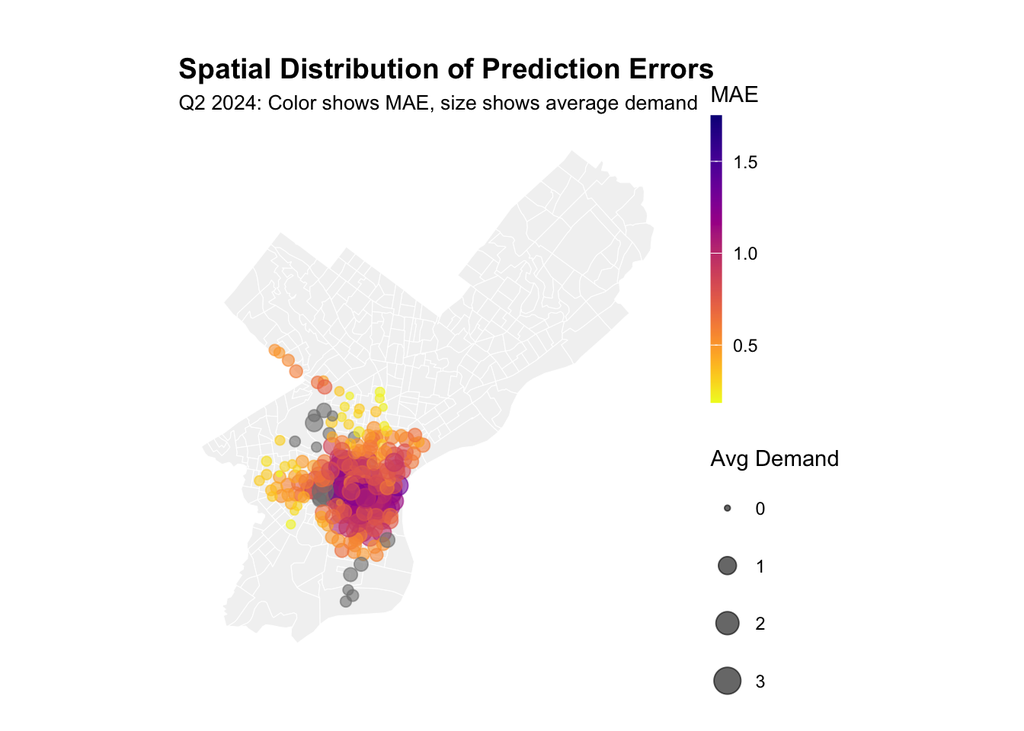

```r
# Calculate error metrics by station
station_errors <- test %>%
  group_by(start_station, start_lat, start_lon) %>%
  summarize(
    MAE = mean(abs_error, na.rm = TRUE),
    RMSE = sqrt(mean(error^2, na.rm = TRUE)),
    mean_error = mean(error, na.rm = TRUE),
    avg_demand = mean(trips, na.rm = TRUE),
    .groups = "drop"
  )

# Create map of prediction errors
ggplot() +
  geom_sf(data = philly_census, fill = "grey95", color = "white", size = 0.1) +
  geom_point(
    data = station_errors,
    aes(x = start_lon, y = start_lat, color = MAE, size = avg_demand),
    alpha = 0.6
  ) +
  scale_color_viridis(
    option = "plasma",
    name = "MAE",
    direction = -1
  ) +
  scale_size_continuous(name = "Avg Demand") +
  labs(
    title = "Spatial Distribution of Prediction Errors",
    subtitle = "Q2 2024: Color shows MAE, size shows average demand"
  ) +
  mapTheme
```

## Temporal Error Patterns

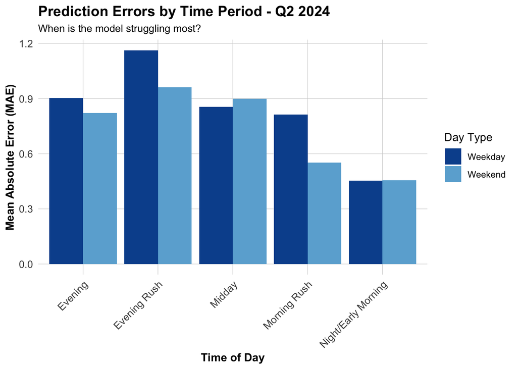

```r
# Calculate MAE by time of day and weekend/weekday
temporal_errors <- test %>%
  group_by(time_of_day, weekend) %>%
  summarize(
    MAE = mean(abs_error, na.rm = TRUE),
    mean_error = mean(error, na.rm = TRUE),
    n_obs = n(),
    .groups = "drop"
  ) %>%
  mutate(day_type = ifelse(weekend == 1, "Weekend", "Weekday"))

# Visualize temporal error patterns
ggplot(temporal_errors, aes(x = time_of_day, y = MAE, fill = day_type)) +
  geom_col(position = "dodge") +
  scale_fill_manual(values = c("Weekday" = "#08519c", "Weekend" = "#6baed6")) +
  labs(
    title = "Prediction Errors by Time Period - Q2 2024",
    subtitle = "When is the model struggling most?",
    x = "Time of Day",
    y = "Mean Absolute Error (MAE)",
    fill = "Day Type"
  ) +
  plotTheme +
  theme(axis.text.x = element_text(angle = 45, hjust = 1))
```

The evening rush hour remains our most challenging period to handle, weekday commuting demand exhibits fluctuations and characteristics that our current models struggle to capture. Weekend error distributions, however, show a smoother pattern, likely because leisure travel tends to be more predictable or regular.

## Demographic Patterns

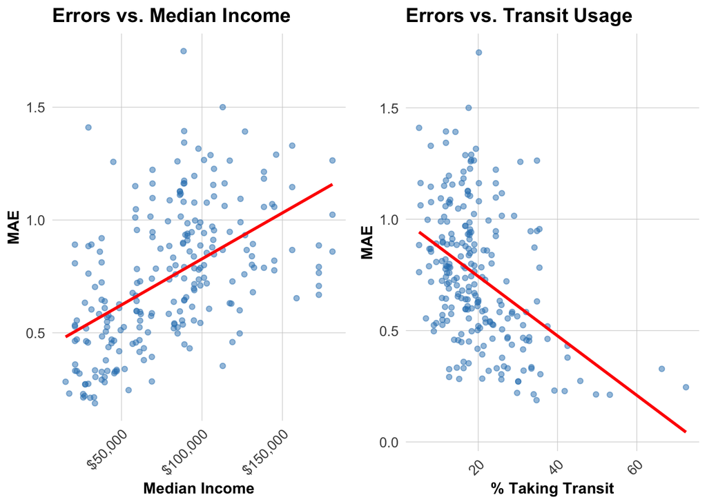

```r
# Join demographic data to station errors
station_errors_demo <- station_errors %>%
  left_join(station_attributes, by = "start_station") %>%
  filter(!is.na(Med_Inc))

# Plot: Income vs errors
p1 <- ggplot(station_errors_demo, aes(x = Med_Inc, y = MAE)) +
  geom_point(alpha = 0.5, color = "#3182bd") +
  geom_smooth(method = "lm", se = FALSE, color = "red") +
  scale_x_continuous(labels = scales::dollar) +
  labs(title = "Errors vs. Median Income", x = "Median Income", y = "MAE") +
  plotTheme

# Plot: Transit usage vs errors
p2 <- ggplot(station_errors_demo, aes(x = Percent_Taking_Transit, y = MAE)) +
  geom_point(alpha = 0.5, color = "#3182bd") +
  geom_smooth(method = "lm", se = FALSE, color = "red") +
  labs(title = "Errors vs. Transit Usage", x = "% Taking Transit", y = "MAE") +
  plotTheme

# Display plots side by side
grid.arrange(p1, p2, ncol = 2)
```

Areas with high public transit usage exhibit more predictable commuter-driven demand patterns (fixed schedules, fixed routes). In contrast, higher-income communities reliant on private vehicles display more volatile, discretionary travel patterns that are harder to predict (corresponding to higher error margins).

# Part 3: Feature Engineering

## New Features

Based on error analysis, we engineered three new features to improve predictions:

```r
# Add new features to both train and test sets
train_improved <- train %>%
  mutate(
    # Feature 1: Memorial Day indicator (May 27, 2024)
    is_memorial_day = ifelse(date == as.Date("2024-05-27"), 1, 0),

    # Feature 2: "Perfect biking weather" (60-75°F, no rain)
    perfect_weather = ifelse(
      temperature >= 60 & temperature <= 75 & precipitation < 0.01,
      1, 0
    ),

    # Feature 3: Rolling 7-day average demand by station
    rolling_7day = lag(trips, 168)  # Simplified 7-day lag
  )

test_improved <- test %>%
  mutate(
    is_memorial_day = ifelse(date == as.Date("2024-05-27"), 1, 0),
    perfect_weather = ifelse(
      temperature >= 60 & temperature <= 75 & precipitation < 0.01,
      1, 0
    ),
    rolling_7day = lag(trips, 168)
  )
```

**Reason for why we added these features:**

1. **Memorial Day indicator**: Holidays often show different demand patterns (like 2.14 in class exercise).
2. **Perfect weather**: It will capture non-linear weather effects better.
3. **7-day rolling average**: It will capture weekly demand trends and specific station patterns

## Improved Model

```r
# Train improved model with new features
model_improved <- lm(
  trips ~ hour + dotw + month + temperature + precipitation +
    lag_1hr + lag_2hr + lag_24hr + Med_Inc + Percent_Taking_Transit +
    temperature:weekend + rush_hour:lag_1hr +
    is_memorial_day + perfect_weather + rolling_7day,
  data = train_improved
)

# Generate predictions
test_improved <- test_improved %>%
  mutate(
    pred_improved = predict(model_improved, newdata = test_improved),
    pred_improved = pmax(pred_improved, 0)
  )
```

```r
# Calculate MAE
mae_improved <- mean(abs(test_improved$trips - test_improved$pred_improved), na.rm = TRUE)
improved_results <- data.frame(
  Metric = c("Improved Model MAE", "Improvement vs Model 5"),
  Value = c(
    round(mae_improved, 3),
    paste0(round((mae5 - mae_improved) / mae5 * 100, 2), "%")
  )
)

kable(improved_results,
      col.names = c("Metric", "Value")) %>%
  kable_styling(bootstrap_options = c("striped", "hover"),
                full_width = FALSE)
```

| Metric | Value |
| --- | --- |
| Improved Model MAE | 0.741 |
| Improvement vs Model 5 | 0.48% |

## Poisson Regression Model

```r
# Since trips are count data, try Poisson regression
model_poisson <- glm(
  trips ~ hour + dotw + month + temperature + precipitation +
    lag_1hr + lag_2hr + lag_24hr + Med_Inc + Percent_Taking_Transit +
    temperature:weekend + rush_hour:lag_1hr,
  data = train,
  family = poisson(link = "log")
)

# Generate predictions
test_poisson <- test %>%
  mutate(
    pred_poisson = predict(model_poisson, newdata = test, type = "response"),
    pred_poisson = pmax(pred_poisson, 0)
  )
```

```r
# Calculate MAE
mae_poisson <- mean(abs(test_poisson$trips - test_poisson$pred_poisson), na.rm = TRUE)
poisson_results <- data.frame(
  Metric = c("Poisson Model MAE", "Comparison to Model 5"),
  Value = c(
    round(mae_poisson, 3),
    paste0(ifelse(mae_poisson < mae5, "Improvement: ", "No improvement: "),
           round(abs(mae5 - mae_poisson) / mae5 * 100, 2), "%")
  )
)

kable(poisson_results,
      col.names = c("Metric", "Value")) %>%
  kable_styling(bootstrap_options = c("striped", "hover"),
                full_width = FALSE)
```

| Metric | Value |
| --- | --- |
| Poisson Model MAE | 0.8 |
| Comparison to Model 5 | No improvement: 7.53% |